# Metodología de la investigación filosófica

# Descripción del curso

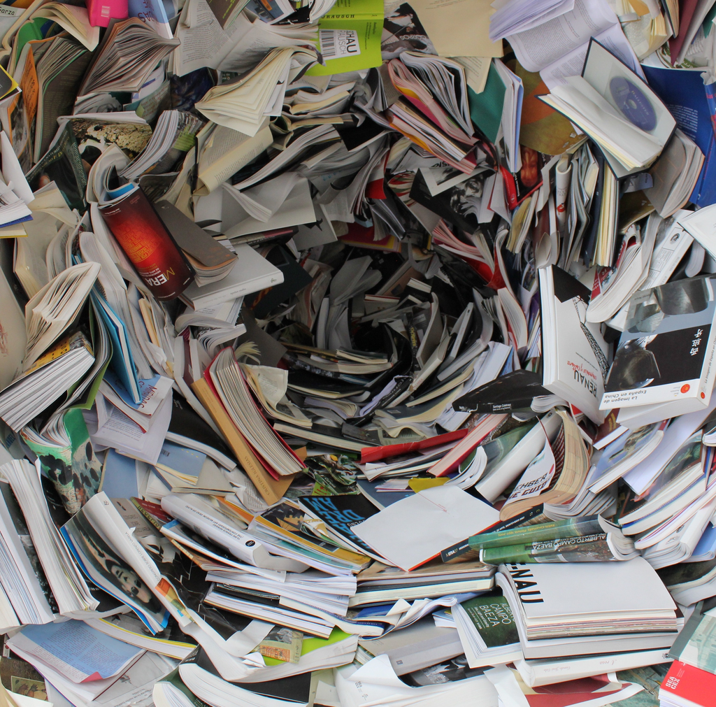

En la monografía de grado, se deben articular los conocimientos adquiridos y las competencias desarrolladas en las asignaturas y seminarios que componen la carrera. Este trabajo de grado consiste en una monografía que estudie un problema filosófico en un autor o corriente, utilizando las metodologías propias de la investigación en filosofía. Debe evidenciarse un conocimiento suficiente de la tradición filosófica relevante, así como un adecuado uso de las fuentes, de la bibliografía secundaria y de los conceptos pertinentes.

El objetivo central de este curso es el diseño de un anteproyecto que sirva para estructurar su trabajo grado. Para ello, se trabajará en pulir y complementar las herramientas obtenidas a lo largo de la carrera, perfilándolas hacia la elaboración de una monografía. Al finalizar este seminario se deberá obtener la aprobación del proyecto de tesis del profesor o profesora que vaya a dirigir el trabajo.

**Docente**: Juan Camilo Espejo-Serna  
**Horario:** Lunes: 12:00 - 3:00 pm.  
**Página web del curso**: http://jcunisabana.github.io/MIF

# Objetivos

1. Identificar un tema de tesis apropiado para el proyecto de investigación.
2. Escribir una primera síntesis del problema filosófico a tratar.
3. Escribir una primera presentación del estado del arte en el tema.
4. Formular una hipótesis de investigación preliminar.
5. Identificar y caracterizar los objetivos de la investigación.
6. Elaborar un primer cronograma de trabajo para terminar la monografía.
7. Realizar una selección de bibliografía relevante para el trabajo de grado.
8. Estar en posición de ofrecer una justificación de la pertinencia de la investigación desde sus antecedentes.
9. Usar adecuadamente el vocabulario y registro propio de la escritura académica.
10. Emplear la gramática, la puntuación y la ortografía adecuada para construir un texto coherente.
11. Utilizar apropiadamente uno de los diferentes estilos de citación reconocidos en la comunidad académica (APA, Chicago, MLA, etc.).

# Contenido temático

*Módulo 1: Identificación de un tema*

Delimitación de un tema. Creación de una primera bibliografía. Lectura estructurada. Retroalimentación entre pares.

*(5 semanas)*

*Módulo 2 - Delimitación de un tema*

Lectura estructurada. Formulación de una hipótesis de investigación. Primera síntesis del asunto a tratar. Búsqueda de directores de tesis. Primera versión del anteproyecto

*(6 semanas)*

*Módulo 3 - Construcción del anteproyecto*

Lectura estructurada. Primeras reuniones con los de directores de tesis. Segunda versión del anteproyecto.

(*6 semanas*)

# Calificación

| *Actividad* | *Valor porcentual* | *Corte* |
| --- | --- | --- |
| Entrega semanal | 15% | 1 |
| Participación | 15% | 1 |
| Entrega semanal | 15% | 2 |
| Participación | 15% | 2 |
| Anteproyecto | 40% | 3 |

#### Entrega semanal

Para cada (casi) todas las semanas, los estudiantes deben leer dos artículos o un capítulo de un libro relevante y producir las reseñas correspondientes según las indicaciones del profesor. La entrega deberá ser subida a la plataforma virtual a más tardar el *24 horas antes de la sesión*. Todos los estudiantes empiezan con 5.0 en esta nota; por cada vez que no se participe dentro del rango de tiempo especificado, la nota será disminuida de acuerdo con los siguientes parámetros: primera vez: -0.5; segunda vez: -1.0; tercera vez: -1.5; cuarta vez: -2.0.

#### Participación

Cada (casi) todas las semanas, se deberá comentar al menos una entrega de sus compañeros. Hagan una pregunta, sugieran bibliografía, propongan un cambio, etc.. Es importante que los comentarios sean articulados y busquen mejorar el texto de sus compañeros. Los comentarios deben ser realizados en las *24 horas siguientes a la clase*. Todos los estudiantes empiezan con 5.0 en esta nota; por cada vez que no se participe dentro del rango de tiempo especificado, la nota será disminuida de acuerdo con los siguientes parámetros: primera vez: -0.5; segunda vez: -1.0; tercera vez: -1.5; cuarta vez: -2.0.(Vean la política sobre incumplimiento de fechas más abajo.)

#### Borrador anteproyecto

Primera versión del anteproyecto siguiendo el formato dado por el profesor.

#### Anteproyecto

Segunda versión del anteproyecto siguiendo el formato dado por el profesor. Debe incluir una defensa oral del proyecto ante compañeros y quien puede ser el posible director o directora.

#### **Incumplimiento**

*La vida nos da sorpresas; sorpresas nos da la vida.* Por eso, todos tienen una entrega “de gracia”. Es decir, pueden dejar de entregar algo sin problema; por ejemplo, la primera reseña que les falte no cuenta. Por ejemplo, si no entregan algo una semana y entregan todos los demás, su nota igual queda en 5.0.

Para todo lo demás, es importante avisar al profesor. Hablemos. No me tienen que contar sus problemas personales pero es importante que si se encuentran en una situación en la que ven que no pueden cumplir con los requerimientos de clase me avisen con la mayor anticipación posible y encontremos un plan para solventar el problema en lo que respecta a la clase. Insisto: hablemos, no se pierdan **:)**.